# Assignment V

Erika Lin

March 5, 2019

### Due Date: Monday March 11, 2019 at 5:59 pm.

## Introduction

We are going to use a simulated two-class data set with 200 observations for training and 100 observations for testing, which includes two features, and in which there is a visible but non-linear separation between the two classes. Use the code below for creating such a dataset.

```r
rm(list = ls())
library(nnet)
library(plyr)
library(dplyr)
library(pROC)
library(caret)
# set a seed
set.seed(1)

# ---- Create a training set ---- #
# create a matrix with 200 rows and two colums with values sampled from a normal distribution.
x <- matrix(rnorm(200*2), ncol = 2)
# Introduce some non-linearity where we move points around
x[1:100,] <- x[1:100,] + 2
x[101:150,] <- x[101:150,] -2
# assign class labels
y <- c(rep(1, 150), rep(0, 50))
# this forms a training set
d.train <- data.frame(x = x, y = as.factor(y))
names(d.train) <- c("X1", "X2", "Y")


# ---- Create a test set ---- #
# create a matrix with 100 rows and two colums with values sampled from a normal distribution.
x <- matrix(rnorm(100*2), ncol = 2)
# Introduce some non-linearity where we move points around
x[1:25,] <- x[1:25,] + 2 # moves points to the top-right of a 2D space
x[26:75,] <- x[26:75,] -2 # moves points to the bottom-left of a 2D space
# assign class labels
y <- c(rep(1, 75), rep(0, 25))
# this forms a testing set
d.test <- data.frame(x = x, y = as.factor(y))
names(d.test) <- c("X1", "X2", "Y")
```

## Question 1

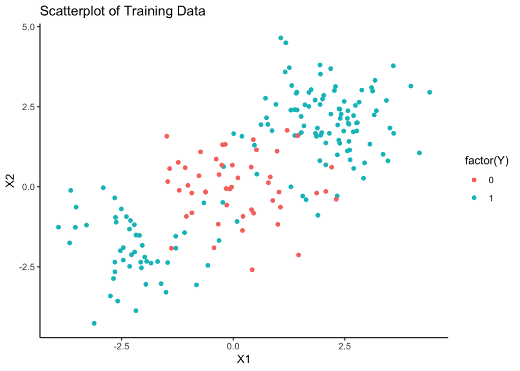

```r
# Insert your code below

library(ggplot2)

sp_train <- ggplot(d.train, aes(x=X1, y=X2)) +
  geom_point(aes(color=factor(Y))) +
  theme_classic()
  plot(sp_train + ggtitle("Scatterplot of Training Data"))
```

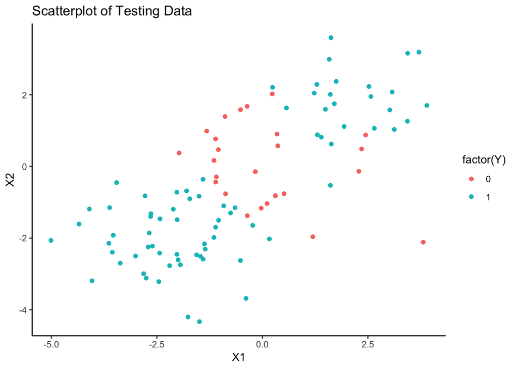

```r
sp_test <- ggplot(d.test, aes(x=X1, y=X2))+
  geom_point(aes(color=factor(Y))) +
  theme_classic()
  plot(sp_test + ggtitle("Scatterplot of Testing Data"))
```

## Question 2

Buid a neural network with a variable hidden layer network size from 2 to 50. Feel free to explore different decay rates using “expand.grid” as shown in class. Perform testing on d.test and report the final AUC with 95% CI.

```r
# Insert your code below
d.train$Y <- ifelse(d.train$Y ==1, "Yes", "No") #assign training dataset column Y to Yes if = 1 else = No
d.test$Y<- ifelse(d.test$Y ==1, "Yes", "No") #assign test dataset columnn Y to Yes if = 1 else = No

#set up a neural network
fit_control <- trainControl(method="cv",
                            number=3,
                            classProbs = TRUE,
                            summaryFunction = twoClassSummary)

#set neural network parameters
nnet_params <- expand.grid(size=seq(from=2,to=50,by=1),
                           decay=5e-4)
head(nnet_params)
```

```
##   size decay
## 1    2 5e-04
## 2    3 5e-04
## 3    4 5e-04
## 4    5 5e-04
## 5    6 5e-04
## 6    7 5e-04
```

```r
#training neural network
nn_train <- train(Y~.,
            data = d.train,
            method = "nnet",
            metric = "ROC",
            trControl = fit_control,
            tuneGrid = nnet_params,
            trace = FALSE)

print(nn_train)
```

```
## Neural Network
##
## 200 samples
##   2 predictor
##   2 classes: 'No', 'Yes'
##
## No pre-processing
## Resampling: Cross-Validated (3 fold)
## Summary of sample sizes: 133, 133, 134
## Resampling results across tuning parameters:
##
##   size  ROC        Sens       Spec
##    2    0.9450245  0.8786765  0.8866667
##    3    0.9428431  0.8002451  0.8866667
##    4    0.9267402  0.7806373  0.8866667
```

[output cut: 50 more lines]

```r
#Prediction on the test dataset
prediction <- predict(nn_train, newdata=d.test, type = "prob")
d.test$Y_prediction <- prediction$Yes #prediction we are looking at is Yes column

#Calculate AUC and 95% CI on test dataset
calculate <- roc(response = d.test$Y, predictor = d.test$Y_prediction, direction = "<")
auc(calculate)
```

```
## Area under the curve: 0.9493
```

```r
ci.auc(calculate)
```

```
## 95% CI: 0.9091-0.9896 (DeLong)
```

## Question 3

1. Build a logistic regression prediction model using d.train. Test on d.test, and report your test AUC.

```r
# Insert your code below
rm(list = ls())
library(nnet)
library(plyr)
library(dplyr)
library(pROC)
library(caret)


# set a seed
set.seed(1)

# ---- Create a training set ---- #
# create a matrix with 200 rows and two colums with values sampled from a normal distribution.
x <- matrix(rnorm(200*2), ncol = 2)
# Introduce some non-linearity where we move points around
x[1:100,] <- x[1:100,] + 2
x[101:150,] <- x[101:150,] -2
# assign class labels
y <- c(rep(1, 150), rep(0, 50))
# this forms a training set
d.train <- data.frame(x = x, y = as.factor(y))
names(d.train) <- c("X1", "X2", "Y")


# ---- Create a test set ---- #
# create a matrix with 100 rows and two colums with values sampled from a normal distribution.
x <- matrix(rnorm(100*2), ncol = 2)
# Introduce some non-linearity where we move points around
x[1:25,] <- x[1:25,] + 2 # moves points to the top-right of a 2D space
x[26:75,] <- x[26:75,] -2 # moves points to the bottom-left of a 2D space
# assign class labels
y <- c(rep(1, 75), rep(0, 25))
# this forms a testing set
d.test <- data.frame(x = x, y = as.factor(y))
names(d.test) <- c("X1", "X2", "Y")

#Logistic regression on the training dataset

train.log <- glm(formula = Y~., data=d.train, family ="binomial")
summary(train.log)
```

```
##
## Call:
## glm(formula = Y ~ ., family = "binomial", data = d.train)
##
## Deviance Residuals:
##      Min        1Q    Median        3Q       Max
## -1.78647   0.04232   0.65101   0.80979   1.09949
##
## Coefficients:
##             Estimate Std. Error z value Pr(>|z|)
## (Intercept)  1.02436    0.16683   6.140 8.24e-10 ***
## X1           0.02316    0.12468   0.186    0.853
## X2           0.17964    0.13086   1.373    0.170
## ---
## Signif. codes:  0 '***' 0.001 '**' 0.01 '*' 0.05 '.' 0.1 ' ' 1
##
## (Dispersion parameter for binomial family taken to be 1)
##
##     Null deviance: 224.93  on 199  degrees of freedom
## Residual deviance: 219.50  on 197  degrees of freedom
## AIC: 225.5
##
## Number of Fisher Scoring iterations: 4
```

```r
#Prediction on the test dataset
d.test$Y_prediction <- predict.glm(train.log, newdata=d.test, type = "response")
d.test$Y_prediction <- ifelse(d.test$Y_prediction >=0.5,1,0) #set this parameter to build a confusion matrix that is binary and numeric

#Calculate AUC on test dataset
prediction <- roc(response = d.test$Y, predictor = d.test$Y_prediction, direction = "<")
auc(prediction)
```

```
## Area under the curve: 0.5
```

2. Which of the two models leads to better performance? Explain in no more than 2 sentences why.

Ans. The neural network model leads to better performance as we are comparing the test and train datasets against each other with a calculated AUC value that evaluates which model is best. The AUC value closest to 1 is desirable, which the neural network model has.